# Project 2: Modelling daily cycling demand in Edinburgh

### 5.3 Long-term trend and extrapolation

This subsection examines the long-term trend in cycling demand implied by the fitted models and considers what that trend means for transport planning. First the estimated annual change is reported, and then its statistical significance, followed by an assessment of whether the trend is robust across M1, M2, and M3, and finally checks whether the COVID period materially affects the estimate, and finaly uses M3 to extrapolate demand forward to 2035 under fixed summer weekday conditions.

Table 3. Trend coefficients from models M1–M3.

| Model | Daily.change..cyclists.day. | Annual.change..cyclists.year. |
| --- | --- | --- |
| M1 | -1.895 | -692 |
| M2 | -1.872 | -683 |
| M3 | -2.152 | -786 |

Table 4. Statistical significance of the trend coefficient in models M1–M3.

| Model | Estimate | Std_Error | t_value | p_value |
| --- | --- | --- | --- | --- |
| M1 | -1.8945 | 0.1392 | -13.61 | 0 |
| M2 | -1.8724 | 0.1390 | -13.47 | 0 |
| M3 | -0.0002 | 0.0000 | -13.92 | 0 |

Table 5. Annual growth rate expressed relative to the predicted count on 1 January 2020.

| Model | Predicted_start_count | Daily_change | Annual_change | Growth_percent |
| --- | --- | --- | --- | --- |
| M1 | 12222.3 | -1.895 | -692 | -5.66 |
| M2 | 12462.5 | -1.872 | -683 | -5.48 |
| M3 | 11512.3 | -2.152 | -786 | -6.82 |

Table 3 and the significance table show that all three models estimate a negative trend in daily cycling demand over the observed period. The trend in M1 corresponds to approximately 692 fewer cyclists per year, in M2 to 683 fewer cyclists per year, and in M3 to about 786 fewer cyclists per year. Expressed relative to the predicted count on 1 January 2020, this corresponds to annual percentage changes of -5.66% in M1, -5.48% in M2, and -6.82% in M3. The trend is statistically significant in all three models, with large negative t-values and p-values effectively equal to zero.

The estimated trend is relatively consistent across M1, M2, and M3. All three models imply an approximate decline of 680–790 cyclists per year. This suggests that the broad direction and magnitude of the trend are reasonably robust to modelling choices. This consistency is useful for planning because it indicates that the conclusion of declining demand is not being driven by one particular specification alone. At the same time, the slightly more negative estimate in M3 shows that allowing for skewness and non-constant variance can shift the implied rate of change somewhat, even if the overall conclusion remains the same.

Table 6. Comparison of M3 trend estimates with and without a COVID indicator.

| Model | Daily_change | Annual_change |
| --- | --- | --- |
| M3 | -2.152 | -786 |
| M3 + COVID | -2.904 | -1060 |

The COVID period seems to be of significance for the interpretation of the long-term trend. With the COVID indicator for model M3, the estimated daily change becomes more negative, shifting from approximately -2.152 cyclists/day to -2.904 cyclists/day. This corresponds to an annual change from about -786 to -1060 cyclists/year, suggesting that the simple linear trend in M3 is partly absorbing the unusual behaviour of the pandemic years. In other words, a single linear trend fitted across 2020–2025 may be too basic, blending together the COVID dip, subsequent recovery, and later pattern into one average slope. This means the trend should be interpreted cautiously rather than treated as a stable structural decline.

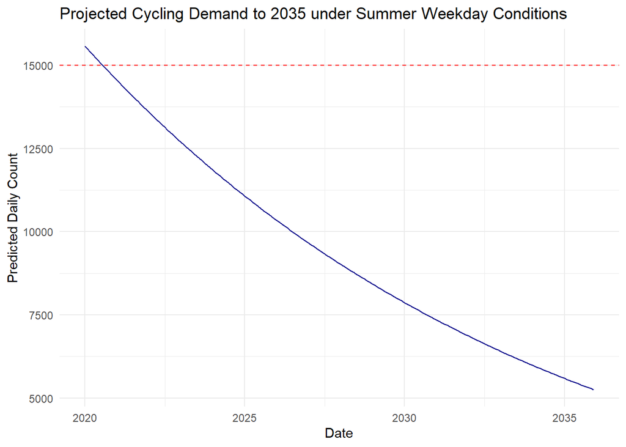

Table 7. Earliest projected date at which predicted summer weekday demand exceeds 15,000 cyclists/day.

| date | pred_count |
| --- | --- |
| 2020-01-01 | 15578.52 |

The extrapolation based on M3 projects declining, rather than increasing, summer weekday cycling demand through to 2035. Using the fitted model we can see that the predicted demand is already above the 15,000 cyclists/day threshold at the start of the period, starting at an estimated value of 15,579 on 1 January 2020. It then falls steadily, where in 15 years, the estimated value for cyclists/day is 5,300. This means that, at the current fitted rate, the model does not predict future growth toward the threshold; instead, it suggests that demand moves away from it over time.

### 5.4 Identifying a poorly-fit period

This subsection examines the residuals of the final model over time in order to identify a specific period in which the model performs notably poorly. The aim is to determine whether the model systematically over- or under-predicts during that period, and to consider what that implies from both a statistical and transport-planning perspective.

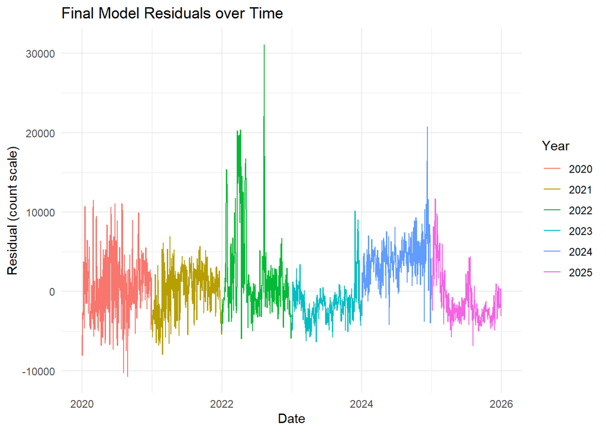

The residual-over-time plot identifues periods where the final model appears to fit particulraly poorly. This can be caused either by residuals that are unusually large in magnitude or because they are persistently positive or negative over a sustained interval.

Table 8. Months with the largest RMSE under the final model.

| year_month | mean_residual | RMSE |
| --- | --- | --- |
| 2022-04 | 8934.418 | 11317.815 |
| 2022-03 | 6851.281 | 10416.665 |
| 2024-12 | 6009.515 | 7866.465 |
| 2022-08 | 3602.210 | 7861.138 |
| 2022-05 | 4191.181 | 7662.392 |
| 2024-10 | 5446.711 | 5885.668 |
| 2025-01 | 4548.762 | 5858.492 |
| 2022-01 | 1747.584 | 5774.558 |
| 2024-11 | 4927.126 | 5598.794 |
| 2024-09 | 4922.280 | 5233.538 |

Table 8 shows the months in which the final model performs worst, ranked by period-specific RMSE. This table will therefore help indicate the exact month with worst performance.

April 2022 stands out as the single poorest-fitted month. It has the largest month-specific RMSE in the table, equal to 11317.8, and a positive mean residual of 8934.4. This indicates that the model under-predicts cyclist demand consistently during this period of time rather than making a few isolated large errors.

This implies April 2022 was a period of unusually high cycling demand that is not fully explained by the variables included in the model. The residual plot shows a large grouping of positive residuals during spring and summer 2022. This suggests that the model may be missing some factor that lifted counts above their usual seasonal level.

From a transport-planning perspective, this reflect changes in travel behavior, especially if cycling demand temporarily increased because of favorable or unfavorable conditions. There was potentially a post-pandemic behavioural shifts, where increased free movement was taken advantage. On the other hand, there may have been external factors such as fuel prices. The Ukraine-Russia war started in Feb.2022 and had resulted in significant increases in the prices of crude oil. Statistically, the poor fit also reflects model limitations: the final model includes temperature, seasonality, day of week, and trend, but omits potentially important short-term drivers such as rainfall, wind, holidays, oil prices and special events. April 2022 therefore appears to be a period where both the data limitations and the model specification contribute to poor predictive performance.

### 5.5 Original Diagnostic Plot

This subsection presents an original plot that is not a standard diagnostic, designed to reveal an interesting feature of the final model that is not visible from standard diagnostics plots. This plot tracks the monthly mean residual over time, showing whether the model systematically over- or under-predicts demand in different periods

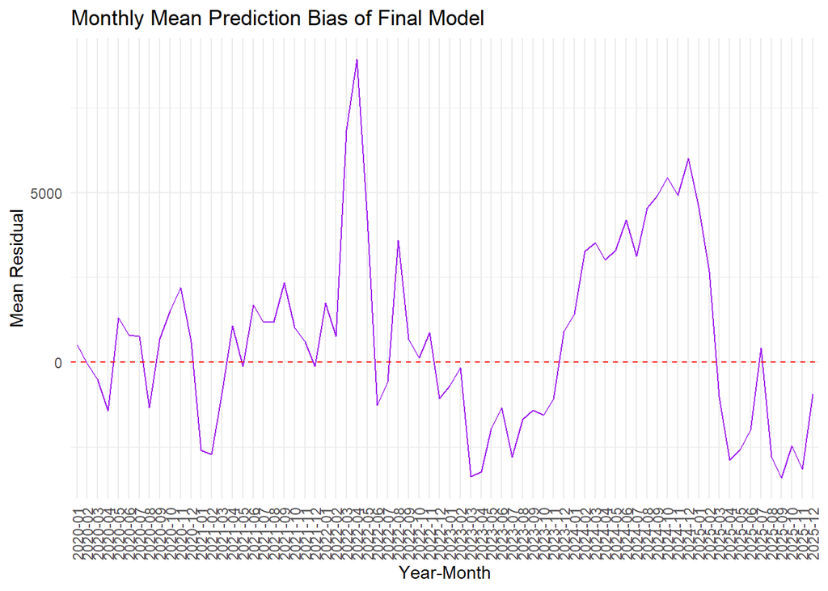

The plot shows the monthly mean residual of the final model over time. Positive values indicate systematic under-prediction and negative values indicate systematic over-prediction. Multiple periods are visibly out, particularly parts of 2022 and late 2024, where the model persistently under-predicts cycling demand, while much of 2025 shows negative mean residuals, indicating over-prediction. A transport planner should conclude that the model captures overall demand patterns reasonably well, but it struggles to track shifts in underlying behaviour across time. In particular, some periods appear to involve sustained changes in demand that are not fully explained by temperature, seasonality, day of week, and trend alone.

This plot is useful because it highlights regional bias rather than just overall error magnitude. Unlike RMSE or QQ plots, it shows when the model is persistently wrong in one direction, which is especially important for planning. A model that repeatedly under-predicts demand during certain periods may lead planners to underestimate pressure on cycling infrastructure, while persistent over-prediction could lead to over-allocation of resources.

All analysis code is in `code.R` and is reproduced below.

```r
# ============================================================
# Project 2: Modelling daily cycling demand in Edinburgh
# Authors: [Karthik Sutheeshkumar], [Kiet Lam], [Leon Godtfredsen]
# ============================================================

#
# Place the code needed in the Report_project02.Rmd, including documentation.
#

# 0. Packages
library(ggplot2); library(dplyr); library(tidyr)
library(lubridate); library(knitr); library(kableExtra)
library(patchwork); library(broom)

# 1. Load data
load('cycle_daily_df.Rdata')

# 2. Data Wrangling
cycle_daily_df <- cycle_daily_df %>%
  mutate(
    month = factor(month, levels = 1:12, ordered = TRUE),

    # Task 2: dow with explicit levels
    dow = factor(dow, levels = c("Sun","Mon","Tue","Wed","Thu","Fri","Sat"), ordered = TRUE),


    # Task 3: trend as integer days since 2020-01-01
    trend = as.integer(date - as.Date("2020-01-01"))
    # Task 1: month as ordered factor for plots/inference

    # Task 2: dow with explicit levels

    # Task 3: trend as integer days since 2020-01-01

  )



# 3. Model Fitting
# Note: Use factor(month) in formulas for M1-M3
model_formulas <- list(
  M0 = count ~ temp_mean + weekend + factor(month),
  M1 = count ~ temp_mean + weekend + trend + factor(month) + factor(dow),
  M2 = count ~ temp_mean + I(temp_mean^2)  + weekend + trend + factor(month) + factor(dow),
  M3 = log(count+1) ~ temp_mean + I(temp_mean^2)+ weekend +trend +factor(month) + factor(dow)
)

m0 <- lm(model_formulas[["M0"]], data = cycle_daily_df)
m1<-lm(model_formulas[["M1"]], data=cycle_daily_df)
m2<- lm(model_formulas[["M2"]], data=cycle_daily_df)
m3<- lm(model_formulas[["M3"]], data=cycle_daily_df)

# 4. Cross-Validation Functions
calc_scores <- function(y, mu, sigma, alpha = 0.05) {
  # y     : vector of observed values
  # mu    : vector of predictive means (from predict(fit, newdata=test)$fit)
  # sigma : vector of predictive SDs. Combine residual error and mean uncertainty:
  #         sigma = sqrt(summary(fit)$sigma^2 + predict(fit, newdata=test, se.fit=TRUE)$se.fit^2)
  # Returns a named list with RMSE, MAE, DS, IS

  # Implement RMSE, MAE, DS, and IS here

  RMSE <- sqrt(mean((y-mu)^2))
  MAE <- mean(abs(y-mu))
  DS <- (y-mu)^2/sigma^2 + 2 * log(sigma)
  l  <- mu - qnorm(1 - alpha/2) * sigma
  u  <- mu + qnorm(1 - alpha/2) * sigma
  IS <- (u-l) + (2/alpha)*pmax(l-y,0) + (2/alpha)*pmax(y-u,0)
  return(list(RMSE = RMSE, MAE = MAE, DS = DS, IS = IS))

}

# 5. Leave-One-Year-Out CV Loop
cycle_cv_df <- cycle_daily_df %>% mutate(month = as.numeric(month))
years <-unique(cycle_cv_df$year)

cv_results <- bind_rows(lapply(names(model_formulas), function(model_name) {
  bind_rows(lapply(years, function(yr) {

    # Splitting into train and test
    test_df  <- cycle_cv_df %>% filter(year == yr)
    train_df <- cycle_cv_df %>% filter(year != yr)

    # Fitting model on training data
    fit <- lm(model_formulas[[model_name]], data = train_df)

    # Predicting on test data
    pred  <- predict(fit, newdata = test_df, se.fit = TRUE)
    mu    <- pred$fit
    sigma <- sqrt(summary(fit)$sigma^2 + pred$se.fit^2)

    # Observed values from test_df
    y <- test_df$count
    if (model_name == "M3") {
      mu_log    <- mu
      sigma_log <- sigma

      # Back-transform to count scale
      mu_count    <- exp(mu_log) - 1
      sigma_count <- exp(mu_log) * sigma_log  # delta method

      y <- test_df$count

      CV_scores <- calc_scores(y, mu_count, sigma_count)

      return(data.frame(
        model = model_name,
        year  = yr,
        RMSE  = CV_scores$RMSE,
        MAE   = CV_scores$MAE,
        DS    = mean(CV_scores$DS),
        IS    = mean(CV_scores$IS)
      ))
    }

    # CV score predictions against observed values
    CV_scores <- calc_scores(y, mu, sigma)

    data.frame(
      model = model_name,
      year  = yr,
      RMSE  = CV_scores$RMSE,
      MAE   = CV_scores$MAE,
      DS    = mean(CV_scores$DS),
      IS    = mean(CV_scores$IS)
    )
  }))
}))

# Table 1: average scores across all held-out years
cv_table1 <- cv_results %>%
  group_by(model) %>%
  summarise(
    RMSE = round(mean(RMSE), 1),
    MAE  = round(mean(MAE), 1),
    DS   = round(mean(DS), 2),
    IS   = round(mean(IS),1),
    .groups = "drop"
  )

print(cv_table1)





# 6. CV by Month


# Create an empty data frame to store observation-level CV predictions
cv_month_data <- cycle_cv_df %>%
  mutate(
    mean_M0 = NA_real_, sd_M0 = NA_real_,
    mean_M1 = NA_real_, sd_M1 = NA_real_,
    mean_M2 = NA_real_, sd_M2 = NA_real_,
    mean_M3 = NA_real_, sd_M3 = NA_real_
  )

# Fill in leave-one-year-out predictions for each model
for (yr in years) {

  train_data <- cycle_cv_df %>% filter(year != yr)
  test_ind   <- which(cycle_cv_df$year == yr)
  test_data  <- cycle_cv_df[test_ind, , drop = FALSE]

  # M0
  fit_M0 <- lm(model_formulas[["M0"]], data = train_data)
  pred_M0 <- predict(fit_M0, newdata = test_data, se.fit = TRUE)
  cv_month_data[test_ind, "mean_M0"] <- pred_M0$fit
  cv_month_data[test_ind, "sd_M0"] <- sqrt(pred_M0$se.fit^2 + summary(fit_M0)$sigma^2)

  # M1
  fit_M1 <- lm(model_formulas[["M1"]], data = train_data)
  pred_M1 <- predict(fit_M1, newdata = test_data, se.fit = TRUE)
  cv_month_data[test_ind, "mean_M1"] <- pred_M1$fit
  cv_month_data[test_ind, "sd_M1"] <- sqrt(pred_M1$se.fit^2 + summary(fit_M1)$sigma^2)

  # M2
  fit_M2 <- lm(model_formulas[["M2"]], data = train_data)
  pred_M2 <- predict(fit_M2, newdata = test_data, se.fit = TRUE)
  cv_month_data[test_ind, "mean_M2"] <- pred_M2$fit
  cv_month_data[test_ind, "sd_M2"] <- sqrt(pred_M2$se.fit^2 + summary(fit_M2)$sigma^2)

  # M3
  fit_M3 <- lm(model_formulas[["M3"]], data = train_data)
  pred_M3 <- predict(fit_M3, newdata = test_data, se.fit = TRUE)
  cv_month_data[test_ind, "mean_M3"] <- pred_M3$fit
  cv_month_data[test_ind, "sd_M3"] <- sqrt(pred_M3$se.fit^2 + summary(fit_M3)$sigma^2)
}

# Compute scores for each observation
score_month <- cv_month_data %>%
  mutate(
    se_M0 = (count - mean_M0)^2,
    ds_M0 = (count - mean_M0)^2 / sd_M0^2 + 2 * log(sd_M0),
    lwr_M0 = mean_M0 - qnorm(0.975) * sd_M0,
    upr_M0 = mean_M0 + qnorm(0.975) * sd_M0,
    is_M0 = (upr_M0 - lwr_M0) +
      (2 / 0.05) * pmax(lwr_M0 - count, 0) +
      (2 / 0.05) * pmax(count - upr_M0, 0),

    se_M1 = (count - mean_M1)^2,
    ds_M1 = (count - mean_M1)^2 / sd_M1^2 + 2 * log(sd_M1),
    lwr_M1 = mean_M1 - qnorm(0.975) * sd_M1,
    upr_M1 = mean_M1 + qnorm(0.975) * sd_M1,
    is_M1 = (upr_M1 - lwr_M1) +
      (2 / 0.05) * pmax(lwr_M1 - count, 0) +
      (2 / 0.05) * pmax(count - upr_M1, 0),

    se_M2 = (count - mean_M2)^2,
    ds_M2 = (count - mean_M2)^2 / sd_M2^2 + 2 * log(sd_M2),
    lwr_M2 = mean_M2 - qnorm(0.975) * sd_M2,
    upr_M2 = mean_M2 + qnorm(0.975) * sd_M2,
    is_M2 = (upr_M2 - lwr_M2) +
      (2 / 0.05) * pmax(lwr_M2 - count, 0) +
      (2 / 0.05) * pmax(count - upr_M2, 0),

    mean_M3_count = exp(mean_M3) - 1,
    se_M3 = (count - mean_M3_count)^2,
    ds_M3 = (log(count + 1) - mean_M3)^2 / sd_M3^2 + 2 * log(sd_M3),
    lwr_M3 = mean_M3 - qnorm(0.975) * sd_M3,
    upr_M3 = mean_M3 + qnorm(0.975) * sd_M3,
    is_M3 = (upr_M3 - lwr_M3) +
      (2 / 0.05) * pmax(lwr_M3 - log(count + 1), 0) +
      (2 / 0.05) * pmax(log(count + 1) - upr_M3, 0)
  )

# Summarise scores by month
cv_table2 <- score_month %>%
  group_by(month) %>%
  summarise(
    RMSE_M0 = round(sqrt(mean(se_M0)), 1),
    MAE_M0  = round(mean(abs(count - mean_M0)), 1),
    DS_M0   = round(mean(ds_M0), 2),
    IS_M0   = round(mean(is_M0), 1),

    RMSE_M1 = round(sqrt(mean(se_M1)), 1),
    MAE_M1  = round(mean(abs(count - mean_M1)), 1),
    DS_M1   = round(mean(ds_M1), 2),
    IS_M1   = round(mean(is_M1), 1),

    RMSE_M2 = round(sqrt(mean(se_M2)), 1),
    MAE_M2  = round(mean(abs(count - mean_M2)), 1),
    DS_M2   = round(mean(ds_M2), 2),
    IS_M2   = round(mean(is_M2), 1),

    RMSE_M3 = round(sqrt(mean(se_M3)), 1),
    MAE_M3  = round(mean(abs(count - mean_M3_count)), 1),
    DS_M3   = round(mean(ds_M3), 2),
    IS_M3   = round(mean(is_M3), 1)
  )

print(cv_table2)

# ...





# ...
```